# **Supervised Machine Learning - Classification**

## Identification of whole blood miRNAs as a diagnostic classifier of colon cancer stage

# Summary

The The Cancer Genome Atlas Program (TCGA) is considered the gold standard for high quality cancer sample datasets. Although there are no plasma or sera derived sample data sets, there are whole blood data, which include microRNA data from Next Generation Sequencing (NGS). In this notebook, a workflow is developed for sequence data pre-processing, transformation, feature selection by differential gene expression and finally comparing multiple machine learning models to classify Early versus Late colon cancer disease outcome. In addition to model performance, interpretability is prioritized as a key factor in model selection for clinical utility.

A 10 miRNA signature is identified, which was best modeled by logistic regression with LASSO trained on z-scored Counts Per Million (CPM) data as determined by cross-validation out-of-fold probability vectors. The LASSO regression model achieved an AUC of 0.745 and the most balanced performance of accurate outcome classification as shown in confusion matrices. Gradient Boosting was also included for predictive performance evaluation and feature importance comparison to the LASSO regression model. Top miRNA features were largely shared among both models.

## Conclusion

Despite the development of a highly interpretable LASSO regression model from 10 whole blood miRNA features, predictive ability was found to be limited (AUC=.745) and could not be improved with hyperparameter tuning. Whole blood is inherently more noisy than circulating miRNA data from sera or plasma due to intracellular leukocyte gene expression, however, important databases such as the TCGA contain only whole blood miRNA data and therefore it is worth considering whether training on a larger patient dataset might improve predictive ability to clinical utility grade in the future.

```python
# NumPy version 2 is more stable for PyDESeq2
!pip install pydeseq2
!pip install "numpy<2"
```

[output not shown]

```python
import os
import glob
import pandas as pd
import matplotlib as plt
import seaborn as sns
import numpy as np
```

```python
# Surpress warnings:
def warn(*args, **kwargs):
    pass
import warnings
warnings.warn = warn
```

# Data Description

## Cohort and Sample Selection

The dataset was accessed from The Cancer Genome Atlas Program (TCGA) https://portal.gdc.cancer.gov/, which hosts various datasets from thousands of primary cancer samples. We will make use of only blood sample data with the goal of developing a diagnostic biomarker for cancer stage from a simple blood draw.  
A cohort of patient samples was created using the following criteria:

- Primary site = colon
- Disease type = Colorectal cancer
- Project ID = CPTAC-2

This resulted in 54 Early cancer patient samples and 50 Late cancer patient samples for a total population size of 104

## Target Variable & Class Distribution

Target class variable is diagnoses.ajcc_pathologic_stage, which refers to the cancer stage diagnosis of each patient. There four stages and within each stage are additional sub-stages. We will combine Stages I and II to class 'Early' and Stages III and IV to 'Late' in order to create a binary classification model.

## Feature Space and Model Building

Features of this dataset are miRNA genes. Each miRNA gene has a count value for each patient sample that corresponds to an estimated copy number of that miRNA gene in the blood sample. The counts of these miRNA genes will be used to train Classification models to predict the Early or Late outcome variable.

# Analysis Objective

## Primary Goal

To construct an accurate predictive classification model capable of differentiating between early-stage and late-stage colorectal cancer (CRC). It will also be desirable to maintain interpretability of the model and identify miRNA features with highest impact on the cancer outcome as this would allow targeted test such as RT-qPCR to be developed rather than performing RNAseq, which is more costly and laborious.

## Supervised Learning Methodological Framework

Multiple models will be tested for their predictive ability as evaluated by multiple common metrics. Hyper-parameter tuning will also be performed to optimize model accuracy as needed

## Clinical Utility

A scalable data-driven tool can assist oncologists in risk-stratifying patients, optimizing treatment pathways, and ultimately improving prognostic outcomes through precise stage classification.

# Data import and pre-processing

104 individual patient miRNA count dataset text files were downloaded from the TCGA portal. These files need to be combined into a single table for analysis.

```python
# create a list of all txt files containing miRNA count tables in folder miRNA counts
globbed_files = glob.glob("/home/robertpyne/PycharmProjects/coursera_module3_classification/miRNA_colorectal_cancer_prediction/data/*.txt")

data = []
for txt in globbed_files:
    frame = pd.read_csv(txt, sep='\t')
    frame['filename'] = os.path.basename(txt)
    data.append(frame)

bigframe = pd.concat(data, ignore_index=True)
bigframe.head()
```

|  | miRNA_ID | read_count | reads_per_million_miRNA_mapped | cross-mapped | filename |
| --- | --- | --- | --- | --- | --- |
| 0 | hsa-let-7a-1 | 48390 | 10121.677668 | N | a4953388-fae9-452f-8698-ddf80435858a.mirnaseq.... |
| 1 | hsa-let-7a-2 | 47569 | 9949.950092 | N | a4953388-fae9-452f-8698-ddf80435858a.mirnaseq.... |
| 2 | hsa-let-7a-3 | 48709 | 10188.402511 | N | a4953388-fae9-452f-8698-ddf80435858a.mirnaseq.... |
| 3 | hsa-let-7b | 17627 | 3687.018232 | N | a4953388-fae9-452f-8698-ddf80435858a.mirnaseq.... |
| 4 | hsa-let-7c | 612 | 128.011298 | N | a4953388-fae9-452f-8698-ddf80435858a.mirnaseq.... |

```python
# filter to only miRNA features and miRNA table
read_count_table = pd.pivot_table(bigframe, values='read_count', index=['filename'], columns=['miRNA_ID'])
read_count_table.head()
```

| miRNA_ID filename | hsa-let-7a-1 | hsa-let-7a-2 | hsa-let-7a-3 | hsa-let-7b | hsa-let-7c | hsa-let-7d | hsa-let-7e | hsa-let-7f-1 | hsa-let-7f-2 | hsa-let-7g | ... | hsa-mir-941-5 | hsa-mir-942 | hsa-mir-943 | hsa-mir-944 | hsa-mir-95 | hsa-mir-9500 | hsa-mir-96 | hsa-mir-98 | hsa-mir-99a | hsa-mir-99b |
| --- | --- | --- | --- | --- | --- | --- | --- | --- | --- | --- | --- | --- | --- | --- | --- | --- | --- | --- | --- | --- | --- |
| 01d0f34d-53b7-451f-817b-f73700cd43b8.mirnaseq.mirnas.quantification.txt | 56023.0 | 55971.0 | 56208.0 | 20321.0 | 6054.0 | 9697.0 | 6006.0 | 48716.0 | 52177.0 | 28612.0 | ... | 0.0 | 12.0 | 0.0 | 1.0 | 240.0 | 0.0 | 66.0 | 8919.0 | 937.0 | 10252.0 |
| 038b557d-25e1-4043-9e6f-d2c2a8e8a4de.mirnaseq.mirnas.quantification.txt | 85075.0 | 84981.0 | 85828.0 | 47241.0 | 6052.0 | 15054.0 | 10807.0 | 56654.0 | 60403.0 | 49294.0 | ... | 0.0 | 13.0 | 0.0 | 0.0 | 417.0 | 0.0 | 1039.0 | 8270.0 | 1327.0 | 21677.0 |
| 04549694-f286-433a-b7cd-b5e88dfbf413.mirnaseq.mirnas.quantification.txt | 78335.0 | 78403.0 | 78343.0 | 45604.0 | 9427.0 | 12571.0 | 19817.0 | 41907.0 | 43669.0 | 33875.0 | ... | 0.0 | 33.0 | 1.0 | 0.0 | 224.0 | 0.0 | 121.0 | 8301.0 | 992.0 | 25254.0 |
| 07633b78-5509-4f7e-859e-4dc42d591161.mirnaseq.mirnas.quantification.txt | 76907.0 | 76684.0 | 77302.0 | 33180.0 | 9759.0 | 13144.0 | 7391.0 | 53976.0 | 57127.0 | 44629.0 | ... | 0.0 | 25.0 | 0.0 | 0.0 | 686.0 | 0.0 | 51.0 | 11197.0 | 2561.0 | 32636.0 |
| 0864b6a3-fa45-49d5-815a-983a096a7eaa.mirnaseq.mirnas.quantification.txt | 39348.0 | 39119.0 | 39645.0 | 14373.0 | 249.0 | 5770.0 | 4032.0 | 34294.0 | 35946.0 | 25913.0 | ... | 0.0 | 28.0 | 0.0 | 0.0 | 361.0 | 0.0 | 484.0 | 6345.0 | 32.0 | 5505.0 |

5 rows × 1881 columns

Metadata including the outcome variable data are in a separate file named "clinical_data.csv"

```python
clinical_df = pd.read_csv("/home/robertpyne/PycharmProjects/coursera_module3_classification/miRNA_colorectal_cancer_prediction/data/clinical_data.csv")
clinical_df.columns.values.tolist()
# one column needs to be removed before merging and the index column header needs to be renamed to match the miRNA count table 'filename'
clinical_df = clinical_df.drop('demographic.submitter_id', axis=1)
clinical_df = clinical_df.drop('cases.case_id', axis=1)
clinical_df.rename(columns={'File Name': 'filename'}, inplace=True)

clinical_df.head()
```

|  | filename | Case ID | demographic.gender | diagnoses.ajcc_pathologic_stage |
| --- | --- | --- | --- | --- |
| 0 | cefac5fb-86d9-41fa-bcba-ca7ffdc3d73d.mirnaseq.... | 11CO010 | female | Stage IIA |
| 1 | 933bd036-3595-4c98-ba19-d530954091c5.mirnaseq.... | 11CO053 | female | Stage IIA |
| 2 | 375fb017-497e-474d-bcd3-aae85c1d0add.mirnaseq.... | 11CO058 | female | Stage IIA |
| 3 | ea001157-8f4d-4ed3-82a7-625fb712422e.mirnaseq.... | 05CO028 | female | Stage I |
| 4 | 901a5f77-a307-467a-bf0f-bb3fbb0ac271.mirnaseq.... | 20CO003 | male | Stage I |

Merge the metadata with the miRNA feature count data

```python
miRNA_count_stage_df = read_count_table.merge(clinical_df, left_on=['filename'], right_on=['filename'])
# now the verbose 'filename' can be deleted because there is a more succinct 'Case ID' identifier column from the clinical_data
miRNA_count_stage_df = miRNA_count_stage_df.drop('filename',axis=1)
# make Case ID the left-most column
col = miRNA_count_stage_df.pop('Case ID')
miRNA_count_stage_df.insert(0, col.name, col)

miRNA_count_stage_df.head()
```

|  | Case ID | hsa-let-7a-1 | hsa-let-7a-2 | hsa-let-7a-3 | hsa-let-7b | hsa-let-7c | hsa-let-7d | hsa-let-7e | hsa-let-7f-1 | hsa-let-7f-2 | ... | hsa-mir-943 | hsa-mir-944 | hsa-mir-95 | hsa-mir-9500 | hsa-mir-96 | hsa-mir-98 | hsa-mir-99a | hsa-mir-99b | demographic.gender | diagnoses.ajcc_pathologic_stage |
| --- | --- | --- | --- | --- | --- | --- | --- | --- | --- | --- | --- | --- | --- | --- | --- | --- | --- | --- | --- | --- | --- |
| 0 | 14CO005 | 56023.0 | 55971.0 | 56208.0 | 20321.0 | 6054.0 | 9697.0 | 6006.0 | 48716.0 | 52177.0 | ... | 0.0 | 1.0 | 240.0 | 0.0 | 66.0 | 8919.0 | 937.0 | 10252.0 | male | Stage II |
| 1 | 16CO002 | 85075.0 | 84981.0 | 85828.0 | 47241.0 | 6052.0 | 15054.0 | 10807.0 | 56654.0 | 60403.0 | ... | 0.0 | 0.0 | 417.0 | 0.0 | 1039.0 | 8270.0 | 1327.0 | 21677.0 | female | Stage IIB |
| 2 | 06CO002 | 78335.0 | 78403.0 | 78343.0 | 45604.0 | 9427.0 | 12571.0 | 19817.0 | 41907.0 | 43669.0 | ... | 1.0 | 0.0 | 224.0 | 0.0 | 121.0 | 8301.0 | 992.0 | 25254.0 | female | Stage IIIC |
| 3 | 05CO055 | 76907.0 | 76684.0 | 77302.0 | 33180.0 | 9759.0 | 13144.0 | 7391.0 | 53976.0 | 57127.0 | ... | 0.0 | 0.0 | 686.0 | 0.0 | 51.0 | 11197.0 | 2561.0 | 32636.0 | female | Stage III |
| 4 | 05CO039 | 39348.0 | 39119.0 | 39645.0 | 14373.0 | 249.0 | 5770.0 | 4032.0 | 34294.0 | 35946.0 | ... | 0.0 | 0.0 | 361.0 | 0.0 | 484.0 | 6345.0 | 32.0 | 5505.0 | female | Stage I |

5 rows × 1884 columns

```python
miRNA_count_stage_df['diagnoses.ajcc_pathologic_stage'].value_counts()
```

```
diagnoses.ajcc_pathologic_stage
Stage IIA     36
Stage IIIB    30
Stage I       12
Stage IIIC     9
Stage IVA      6
Stage IIB      4
Stage IIIA     3
Stage II       2
Stage III      1
Stage IV       1
'--            1
Name: count, dtype: int64
```

We consolidate the disease sub-stages

```python
# there is one case with no phenotype value "'--" that should be removed
miRNA_count_stage_df.drop(miRNA_count_stage_df[miRNA_count_stage_df['diagnoses.ajcc_pathologic_stage'] == "'--"].index, inplace = True)

# sub-stages will not be considered, only 5 cancer stages will be considered so the values in 'diagnoses.ajcc_pathologic_stage' are modified as such
miRNA_count_stage_df.loc[miRNA_count_stage_df["diagnoses.ajcc_pathologic_stage"] == "Stage IIA", "diagnoses.ajcc_pathologic_stage"] = "Stage II"
miRNA_count_stage_df.loc[miRNA_count_stage_df["diagnoses.ajcc_pathologic_stage"] == "Stage IIB", "diagnoses.ajcc_pathologic_stage"] = "Stage II"
miRNA_count_stage_df.loc[miRNA_count_stage_df["diagnoses.ajcc_pathologic_stage"] == "Stage IIIA", "diagnoses.ajcc_pathologic_stage"] = "Stage III"
miRNA_count_stage_df.loc[miRNA_count_stage_df["diagnoses.ajcc_pathologic_stage"] == "Stage IIIB", "diagnoses.ajcc_pathologic_stage"] = "Stage III"
miRNA_count_stage_df.loc[miRNA_count_stage_df["diagnoses.ajcc_pathologic_stage"] == "Stage IIIC", "diagnoses.ajcc_pathologic_stage"] = "Stage III"
miRNA_count_stage_df.loc[miRNA_count_stage_df["diagnoses.ajcc_pathologic_stage"] == "Stage IVA", "diagnoses.ajcc_pathologic_stage"] = "Stage IV"
miRNA_count_stage_df.loc[miRNA_count_stage_df["diagnoses.ajcc_pathologic_stage"] == "Stage IVB", "diagnoses.ajcc_pathologic_stage"] = "Stage IV"

miRNA_count_stage_df['diagnoses.ajcc_pathologic_stage'].value_counts()
```

```
diagnoses.ajcc_pathologic_stage
Stage III    43
Stage II     42
Stage I      12
Stage IV      7
Name: count, dtype: int64
```

This imbalance among classes would be too problematic to pursue a multi-class prediction model. Instead, create 'Early' (Stage I and II) and 'Late' (Stage III and IV) classes

```python
miRNA_count_stage_df.loc[miRNA_count_stage_df["diagnoses.ajcc_pathologic_stage"] == "Stage I", "diagnoses.ajcc_pathologic_stage"] = "Early"
miRNA_count_stage_df.loc[miRNA_count_stage_df["diagnoses.ajcc_pathologic_stage"] == "Stage II", "diagnoses.ajcc_pathologic_stage"] = "Early"
miRNA_count_stage_df.loc[miRNA_count_stage_df["diagnoses.ajcc_pathologic_stage"] == "Stage III", "diagnoses.ajcc_pathologic_stage"] = "Late"
miRNA_count_stage_df.loc[miRNA_count_stage_df["diagnoses.ajcc_pathologic_stage"] == "Stage IV", "diagnoses.ajcc_pathologic_stage"] = "Late"

miRNA_count_stage_df['diagnoses.ajcc_pathologic_stage'].value_counts()
```

```
diagnoses.ajcc_pathologic_stage
Early    54
Late     50
Name: count, dtype: int64
```

```python
miRNA_count_stage_df.set_index('Case ID', inplace=True)
```

## Export preprocessed count data table

```python
miRNA_count_stage_df.to_csv('miRNA_count_data_preprocessed.csv')
```

## Filter low read count miRNA features

miRNAseq data is sparse because many miRNA genes are barely expressed and therefore are not biologically relevant. It therefore makes sense to remove such lowly expressed genes before proceeding with further analysis.

```python
import pandas as pd

def filter_by_cpm(counts_df, cpm_threshold=1, min_samples=10):
    """
    Calculates CPM on numeric data and returns the normalized dataframe
    and the list of miRNAs passing the expression threshold.
    """
    # 1. Isolate numeric expression columns
    numeric_df = counts_df.select_dtypes(include=['number'])

    # 2. Calculate CPM (assuming Samples are Rows, miRNAs are Columns)
    cpm_df = numeric_df.div(numeric_df.sum(axis=1), axis=0) * 1e6
    cpm_df = cpm_df.fillna(0) # Safeguard against zero-read samples

    # 3. Extract columns that meet the threshold criteria
    keep_mask = (cpm_df > cpm_threshold).sum(axis=0) >= min_samples
    keep_miRNAs = cpm_df.columns[keep_mask].tolist()

    print(f"CPM Filter: {len(keep_miRNAs)} miRNAs retained out of {numeric_df.shape[1]}.")

    return cpm_df, keep_miRNAs
```

Now use the filter_by_cpm function to generate a list of miRNAs expressed at a biologically meaningful level and use that list to create filtered raw count and CPM data frames. Also create a metadat dataframe containing gender and cancer stage data.

```python
# 1. Run filtering function to generate a list of highly expressed miRNAs
cpm_df, keep_miRNAs = filter_by_cpm(miRNA_count_stage_df, cpm_threshold=1, min_samples=10)

counts_filtered = miRNA_count_stage_df[keep_miRNAs]
cpm_filtered = cpm_df[keep_miRNAs]
meta_df = miRNA_count_stage_df[['demographic.gender', 'diagnoses.ajcc_pathologic_stage']].copy()
```

```
CPM Filter: 621 miRNAs retained out of 1881.
```

# Exploratory Data Analysis

Here are some important aspects of the pre-processed dataset:

- miRNA feature count data is sparse and follows a Poisson distirbutiopn with dispersion (noisy)
- two-class outcome variable ('Late' vs. 'Early')
- gender is an important covariate that needs to be considered before moving forward to model development

```python
print(miRNA_count_stage_df.shape)
pd.crosstab(miRNA_count_stage_df['diagnoses.ajcc_pathologic_stage'], miRNA_count_stage_df['demographic.gender'], margins=True,
    margins_name='Total')
```

```
(104, 1883)
```

| demographic.gender diagnoses.ajcc_pathologic_stage | female | male | Total |
| --- | --- | --- | --- |
| Early | 30 | 24 | 54 |
| Late | 31 | 19 | 50 |
| Total | 61 | 43 | 104 |

```python
miRNA_count_stage_df.shape
```

```
(104, 1883)
```

## Data distribution

One common characteristic of all RNAseq data is that each sample is not sequenced to the same extent. Whereas one sample may have 15 million total sequences another may have 9 million. Therefore, some form of normalization must occur, for example, scaling count data to Counts Per Million (CPM) by simply dividing the raw miRNA count be total counts of the sample and multiplying by 1 million. miRNA count data follow a Negative Binomial / Poisson distributions in which the variance increases with the mean, which violates the homoscedasticity assumption required for standard parametric tests. To account for this, we will test two methods of variance stabilization:

- Variance-Stabilizing-Transformation (VST) relies on the Negative Binomial / Poisson distributions to calculate exactly how much of a gene's variance is just random "sequencing noise" and how much is true biological variance. It is a "global" method that squeezes variance of weakly expressed miRNA features unlike log2 transformation, which artificially inflates lowly expressed genes.
- log2(CPM) + 1 transformation

We can have a look at how each method affect the distributions for each sample.

```python
import numpy as np
import pandas as pd
from pydeseq2.dds import DeseqDataSet

def extract_normalized_matrices(filtered_counts_df, filtered_cpm_df, metadata_df, target_col='diagnosis'):
    """
    Accepts pre-filtered counts, a pre-computed CPM matrix, and metadata.
    Calculates Log2(CPM + 1) and executes PyDESeq2 to extract the
    Variance Stabilizing Transformation (VST) matrix.

    Returns:
    --------
    log_cpm_df : pandas.DataFrame
    vst_df : pandas.DataFrame
    """
    # 1. Calculate Log2(CPM + 1) directly using your incoming pre-computed cpm_df
    # We slice it using filtered_counts_df.columns to keep only the passing miRNAs
    log_cpm_df = np.log2(filtered_cpm_df[filtered_counts_df.columns] + 1)

    # 2. Sanitize metadata target column name for the PyDESeq2 formula parser
    clean_meta = metadata_df.copy()
    safe_col_name = target_col.replace('.', '_').replace(' ', '_').replace('-', '_')
    clean_meta[safe_col_name] = clean_meta[target_col]

    # 3. Fit PyDESeq2 using the pre-filtered count matrix
    # (Enforcing integer types right inside the constructor for safety)
    dds = DeseqDataSet(
        counts=filtered_counts_df.astype(int),
        metadata=clean_meta,
        design_factors=safe_col_name
    )
    dds.deseq2()
    dds.vst()

    # 4. Extract and wrap VST array back into a structural DataFrame
    vst_df = pd.DataFrame(
        dds.layers["vst_counts"],
        index=filtered_counts_df.index,
        columns=filtered_counts_df.columns
    )

    return log_cpm_df, vst_df
```

```python
log_cpm_df, vst_df = extract_normalized_matrices(counts_filtered, cpm_filtered, meta_df, target_col='diagnoses.ajcc_pathologic_stage')
```

```
Using None as control genes, passed at DeseqDataSet initialization
```

[output not shown]

```
Fit type used for VST : parametric
Using None as control genes, passed at DeseqDataSet initialization
```

```
Fitting dispersions...
... done in 0.70 seconds.
```

We now have filtered CPM, log2(CPM +1) and VST data frames. Let's plot them to see how the data distributions vary

```python
print(cpm_filtered.shape)
print(log_cpm_df.shape)
print(vst_df.shape)
```

```
(104, 621)
(104, 621)
(104, 621)
```

```python
import matplotlib.pyplot as plt
import seaborn as sns
from sklearn.decomposition import PCA

def plot_variance_comparison(cpm_filtered, log_cpm_df, vst_df):
    """
    Takes the raw counts, pre-computed Log2 matrix, and pre-computed VST matrix
    to generate the 3-panel vertical distribution boxplots.
    """

    # 1. Melt long structures for Seaborn
    long_cpm = cpm_filtered.T.melt(var_name='Sample', value_name='CPM')
    long_log = log_cpm_df.T.melt(var_name='Sample', value_name='Log2_CPM')
    long_vst = vst_df.T.melt(var_name='Sample', value_name='VST')

    # 2. Canvas setup
    num_samples = cpm_filtered.shape[0]
    fig, axes = plt.subplots(3, 1, figsize=(max(14, num_samples * 0.3), 16), sharex=True)
    sns.set_theme(style="whitegrid")

    # Panel 1: Filtered CPM
    sns.boxplot(data=long_cpm, x='Sample', y='CPM', ax=axes[0], color='#d62728', fliersize=1.0, linewidth=0.8)
    axes[0].set_title('1. Un-normalized Expression (Raw CPM Scale)', fontsize=12, fontweight='bold', pad=8)
    axes[0].set_ylabel('Expression (CPM)', fontsize=10, fontweight='bold')

    # Panel 2: Log2(CPM + 1)
    sns.boxplot(data=long_log, x='Sample', y='Log2_CPM', ax=axes[1], color='#1f77b4', fliersize=1.0, linewidth=0.8)
    axes[1].set_title('2. Standard Log-Transformation (Log2(CPM + 1))', fontsize=12, fontweight='bold', pad=8)
    axes[1].set_ylabel('Log2(CPM + 1)', fontsize=10, fontweight='bold')

    # Panel 3: VST
    sns.boxplot(data=long_vst, x='Sample', y='VST', ax=axes[2], color='#2ca02c', fliersize=1.0, linewidth=0.8)
    axes[2].set_title('3. Advanced Normalization (Variance Stabilizing Transformation - VST)', fontsize=12, fontweight='bold', pad=8)
    axes[2].set_ylabel('VST Values', fontsize=10, fontweight='bold')
    axes[2].set_xlabel('Individual Samples', fontsize=11, fontweight='bold')

    axes[2].set_xticklabels(axes[2].get_xticklabels(), rotation=90, fontsize=8)

    plt.suptitle('Comparison of Data Transformations on miRNA Variance Profiles', fontsize=15, fontweight='bold', y=0.99)
    plt.tight_layout()
    plt.show()
```

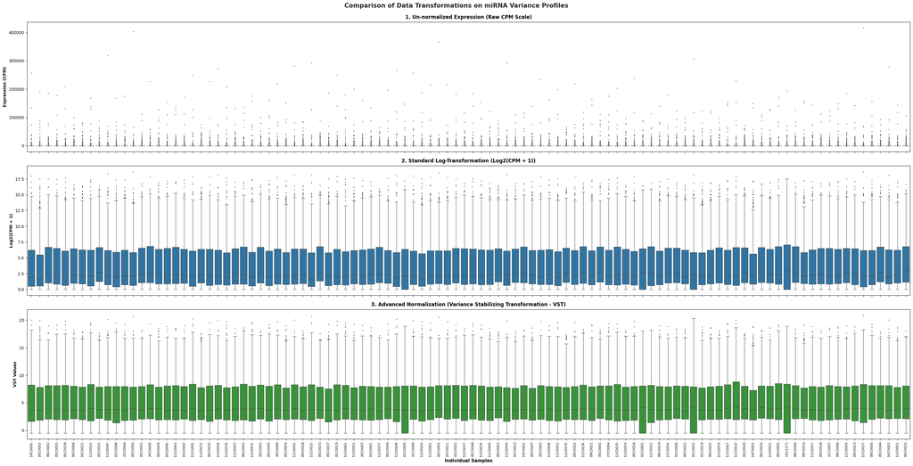

```python
plot_variance_comparison(cpm_filtered, log_cpm_df, vst_df)
```

The severe skew of the CPM data is evident in the top sub-plot while the VST and log2(CPM +1) show distributions that are still skewed but much closer to a normal distribution. We have data frames for each set so we can compare how each performs in the machine learning models later.

# Feature Selection

In the current data, there are 621 microRNAs, many of these are uniformative because they have very low variance across samples. We can build a stronger model by capturing those microRNA features that have significantly different counts among the Early and Late outcome classes

## Differentially expressed miRNAs (DEMs)

There are a number of packages for gene differential expression, most of which are written in R. I would like to continue to use Python so we will use a Python implementation of the R package DESeq2 called PyDESeq2. A Two Sample Wald Test to test for log2 expression changes in Early vs. Late stage cancer samples as well as Male versus Female to ensure Gender is not a confounding variable

```python
import pandas as pd
from pydeseq2.dds import DeseqDataSet
from pydeseq2.ds import DeseqStats

# ==========================================
# ANALYSIS 1: Early vs. Late (Controlling for Gender)
# ==========================================
print("--- Running Analysis 1: Early vs. Late ---")

# 1. Design formula includes 'gender' first as a covariate, then 'diagnosis' as the main factor
dds_stage = DeseqDataSet(
    counts=counts_filtered.astype(int),
    metadata=meta_df,
    design_factors=["demographic.gender", "diagnoses.ajcc_pathologic_stage"],
    quiet=True
)
dds_stage.deseq2()

# 2. Extract stats contrasting Late vs Early
stat_stage = DeseqStats(dds_stage, contrast=["diagnoses.ajcc_pathologic_stage", "Late", "Early"], quiet=True)
stat_stage.summary()
res_stage_df = stat_stage.results_df.sort_values('pvalue')


# ==========================================
# ANALYSIS 2: Male vs. Female (Controlling for Stage)
# ==========================================
print("\n--- Running Analysis 2: Male vs. Female ---")

# 1. Design formula includes 'diagnosis' first as a covariate, then 'gender' as the main factor
dds_sex = DeseqDataSet(
    counts=counts_filtered.astype(int),
    metadata=meta_df,
    design_factors=["diagnoses.ajcc_pathologic_stage", "demographic.gender"],
    quiet=True
)
dds_sex.deseq2()

# 2. Extract stats contrasting Male vs Female
stat_sex = DeseqStats(dds_sex, contrast=["demographic.gender", "male", "female"], quiet=True)
stat_sex.summary()
res_sex_df = stat_sex.results_df.sort_values('pvalue')
```

```
--- Running Analysis 1: Early vs. Late ---

--- Running Analysis 2: Male vs. Female ---
```

```python
# miRNAs changing significantly between stages, independent of patient gender
significant_stage = res_stage_df[res_stage_df['padj'] < 0.05]
print(f"Found {len(significant_stage)} miRNAs associated with Cancer Stage.")

# --- Print Top 10 Table Regardless of Significance Threshold ---
print("\nTop 10 Differentially Expressed miRNAs (Late vs Early):")
print(f"{'miRNA':<25} | {'padj':<12} | {'log2FC':<8} | {'Direction'}")
print("-" * 60)

# Take the top 10 rows directly from the sorted master dataframe
top_10_stage = res_stage_df.head(10)

for mirna in top_10_stage.index:
    padj = top_10_stage.loc[mirna, 'padj']
    l2fc = top_10_stage.loc[mirna, 'log2FoldChange']
    direction = "UP in Late" if l2fc > 0 else "DOWN in Late"
    print(f"{mirna:<25} | {padj:<12.4e} | {l2fc:<8.2f} | {direction}")
```

```
Found 5 miRNAs associated with Cancer Stage.

Top 10 Differentially Expressed miRNAs (Late vs Early):
miRNA                     | padj         | log2FC   | Direction
------------------------------------------------------------
hsa-mir-1304              | 3.1081e-04   | 1.28     | UP in Late
hsa-mir-224               | 2.0271e-02   | 0.76     | UP in Late
hsa-mir-155               | 2.0271e-02   | -0.58    | DOWN in Late
hsa-mir-451a              | 2.0271e-02   | 0.89     | UP in Late
hsa-mir-615               | 3.4954e-02   | -1.38    | DOWN in Late
hsa-mir-551a              | 8.4051e-02   | -1.41    | DOWN in Late
hsa-mir-675               | 8.6103e-02   | 1.27     | UP in Late
hsa-mir-1247              | 2.2407e-01   | 1.03     | UP in Late
hsa-mir-181b-1            | 3.1228e-01   | -0.38    | DOWN in Late
hsa-mir-511               | 3.1228e-01   | -0.41    | DOWN in Late
```

Given our alpha = 0.05 threshold, we have 5 miRNAs that can be considered differentially expressed among late versus early sample groups. Furthermore, we can confirm there are no individual miRNA features differing among Biological Sex.

```python
# miRNAs changing significantly between sexes, independent of cancer stage
significant_sex = res_sex_df[res_sex_df['padj'] < 0.05]
print(f"Found {len(significant_sex)} miRNAs associated with Biological Sex.")
```

```
Found 0 miRNAs associated with Biological Sex.
```

## Global miRNA expression Changes

We can also plot the magnitude of gene expression differences across all miRNAs to get a sense of the global change between Early and Late outcome classes. To do so we will make a volcano plot, which shows the distribution of miRNA features according to their log2 fold change and adjusted p value

```python
import numpy as np
import pandas as pd
import matplotlib.pyplot as plt
import seaborn as sns

def plot_volcano(res_df, padj_threshold=0.05, l2fc_threshold=1.0, top_n_labels=10):
    """
    Generates a high-resolution Volcano Plot from PyDESeq2 results.

    Parameters:
    - res_df: DataFrame containing results from 'stat_stage.results_df'
    - padj_threshold: Adjusted p-value significance cutoff (default: 0.05)
    - l2fc_threshold: absolute Log2 Fold Change cutoff (default: 1.0)
    - top_n_labels: Number of top significant miRNAs to explicitly label on the plot
    """
    # Create a copy to prevent modifying the original dataframe
    plot_data = res_df.dropna(subset=['padj', 'log2FoldChange']).copy()

    # Calculate -log10(padj) for the y-axis
    # Adding a tiny epsilon prevents log10(0) issues if p-values are extremely small
    plot_data['-log10_padj'] = -np.log10(plot_data['padj'] + 1e-300)

    # Classify miRNAs into categories for coloring
    conditions = [
        (plot_data['padj'] < padj_threshold) & (plot_data['log2FoldChange'] > l2fc_threshold),
        (plot_data['padj'] < padj_threshold) & (plot_data['log2FoldChange'] < -l2fc_threshold)
    ]
    choices = ['Up-regulated in Late', 'Down-regulated in Late']
    plot_data['Significance'] = np.select(conditions, choices, default='Not Significant')

    # Setup plot aesthetics
    plt.figure(figsize=(10, 8))
    sns.set_theme(style="whitegrid")

    # Color palette matching standard genomics publications
    color_dict = {
        'Up-regulated in Late': '#1f77b4',     # Red
        'Down-regulated in Late': '#d62728',   # Blue
        'Not Significant': '#949c94'          # Muted Grey
    }

    # Draw the scatter plot
    sns.scatterplot(
        data=plot_data,
        x='log2FoldChange',
        y='-log10_padj',
        hue='Significance',
        palette=color_dict,
        alpha=0.8,
        edgecolor=None,
        s=45
    )

    # Draw threshold cut-off lines
    plt.axhline(-np.log10(padj_threshold), color='black', linestyle='--', linewidth=1, alpha=0.7)
    plt.axvline(l2fc_threshold, color='black', linestyle='--', linewidth=1, alpha=0.7)
    plt.axvline(-l2fc_threshold, color='black', linestyle='--', linewidth=1, alpha=0.7)

    # Text annotations for the top N most significant miRNAs
    # Sorting by raw padj (not log transformed) ensures we pull the absolute top entries
    top_miRNAs = plot_data.sort_values('padj').head(top_n_labels)

    for mirna in top_miRNAs.index:
        x = top_miRNAs.loc[mirna, 'log2FoldChange']
        y = top_miRNAs.loc[mirna, '-log10_padj']

        # Slightly offset text to prevent overlap with the dot
        plt.text(
            x + (0.05 if x > 0 else -0.05),
            y + 0.1,
            mirna,
            fontsize=9,
            fontweight='bold',
            ha='left' if x > 0 else 'right',
            va='bottom'
        )

    # Titles and Labels
    plt.title('Differential miRNA Expression: Late vs. Early Stage Diagnosis', fontsize=16, fontweight='bold', pad=15)
    plt.xlabel('Log2 Fold Change (Late / Early)', fontsize=13, fontweight='bold')
    plt.ylabel('-log10 Adjusted P-Value', fontsize=13, fontweight='bold')

    # Clean up legend placement
    plt.legend(title='Expression Status', title_fontsize='11', loc='upper right', frameon=True)

    # Adjust axes limits dynamically to look centered and spacious
    max_x = max(abs(plot_data['log2FoldChange'].min()), abs(plot_data['log2FoldChange'].max())) + 0.5
    plt.xlim(-max_x, max_x)

    plt.tight_layout()
    plt.show()
```

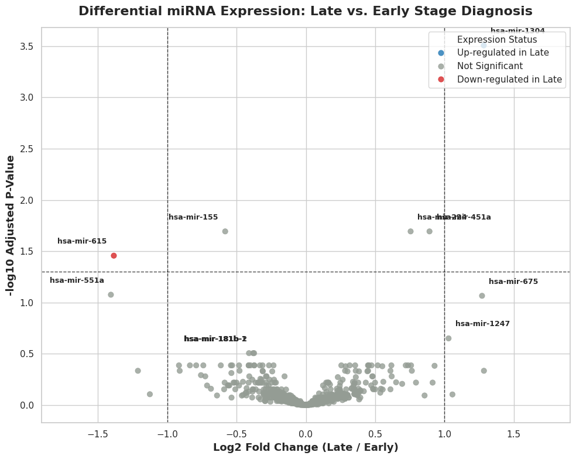

```python
plot_volcano(res_stage_df, padj_threshold=0.05, l2fc_threshold=1.0)
```

# Classification Model Evaluation

Having identified miRNA features with evidence for differential expression according to cancer stage, we will create a feature selection subset that will be used to train multiple Supervised Classification models and compare for performance. The goal is to identify clean decision boundaries while avoiding overfitting as well as providing explainability of the model as the ultimate application would be for clinical use and must therefore maintain high interpretability. The models will be:

- Logistic regression with LASSO penalization
- Support Machinen Vector
- Random Forest
- Gradient Boosting

## Create X and y datasets for model training

Five miRNA features were identified as differentially expressed among Early and Late outcome classes but we will extend the feature selection to the top 10 miRNA features according to the lowest adjusted p value with the hope that our machine learning model will make use of the variance from the additional five miRNA features. Counts Per Million (CPM) and Variance Stabilized (VST) data frames will be modeled in parallel to see how they perform subjected to each model.

```python
# Change top_x to whatever number you need
top_x = 10
# Drop NaNs to ignore filtered outliers, then grab the top X miRNA names
top_mirna_list = res_stage_df.dropna(subset=['pvalue']).head(top_x).index.tolist()

X_vst = vst_df[top_mirna_list].copy()
X_cpm = cpm_filtered[top_mirna_list].copy()

target_col = "diagnoses.ajcc_pathologic_stage"
y = meta_df[target_col]

print(f"VST subset shape: {X_vst.shape}")
print(f"CPM subset shape: {X_cpm.shape}")
print(f"y subset shape: {y.shape}")
```

```
VST subset shape: (104, 10)
CPM subset shape: (104, 10)
y subset shape: (104,)
```

```python
X_vst.head()
```

| Case ID | hsa-mir-1304 | hsa-mir-224 | hsa-mir-155 | hsa-mir-451a | hsa-mir-615 | hsa-mir-551a | hsa-mir-675 | hsa-mir-1247 | hsa-mir-181b-1 | hsa-mir-511 |
| --- | --- | --- | --- | --- | --- | --- | --- | --- | --- | --- |
| 14CO005 | 2.764243 | 11.495234 | 10.982777 | 11.886475 | 6.565444 | 1.067407 | 3.504940 | 9.454265 | 10.625654 | 4.925956 |
| 16CO002 | 2.912167 | 11.192703 | 8.829593 | 10.462796 | 5.291029 | 0.956306 | 2.577641 | 11.113695 | 13.310819 | 4.368828 |
| 06CO002 | 3.331764 | 12.302333 | 11.186611 | 10.762735 | 4.701531 | -0.477891 | 3.331764 | 8.125715 | 11.586227 | 5.959138 |
| 05CO055 | 2.480713 | 13.626112 | 10.867834 | 10.370367 | 3.903361 | 1.564092 | 1.942904 | 11.460477 | 10.951107 | 3.983022 |
| 05CO039 | 3.621132 | 9.593286 | 10.142191 | 11.360657 | 8.267445 | -0.477891 | 1.896114 | 3.112719 | 11.377846 | 5.239960 |

```python
X_cpm.head()
```

| Case ID | hsa-mir-1304 | hsa-mir-224 | hsa-mir-155 | hsa-mir-451a | hsa-mir-615 | hsa-mir-551a | hsa-mir-675 | hsa-mir-1247 | hsa-mir-181b-1 | hsa-mir-511 |
| --- | --- | --- | --- | --- | --- | --- | --- | --- | --- | --- |
| 14CO005 | 1.327560 | 704.934163 | 494.073442 | 924.645282 | 22.789774 | 0.221260 | 2.433859 | 171.033932 | 385.656072 | 7.080318 |
| 16CO002 | 1.237562 | 469.963995 | 91.115468 | 283.246897 | 7.580064 | 0.154695 | 0.928171 | 444.903374 | 2041.203065 | 3.867380 |
| 06CO002 | 3.181319 | 1849.937169 | 853.388900 | 635.998749 | 9.013738 | 0.000000 | 3.181319 | 101.802217 | 1125.921920 | 22.269235 |
| 05CO055 | 1.347064 | 4018.293135 | 593.516579 | 420.284096 | 4.310606 | 0.538826 | 0.808239 | 895.259007 | 628.809667 | 4.580019 |
| 05CO039 | 2.546469 | 179.950463 | 263.418052 | 613.416043 | 71.584068 | 0.000000 | 0.565882 | 1.697646 | 620.772508 | 8.488229 |

## Baseline classifiers

Here we create classifiers without hyper parameter tuning to get an initial sense for how they perform with each dataset. The Tree-Based Models (Random Forest / Gradient Boosting) can easily ingest VST or CPM data because they handle non-linear adjustments natively (without scaling). In contrast, the Linear/Distance Models (Logistic Regression with LASSO / SVM) are highly sensitive and therefore should be scaled with StandardScaler() before training. Even with VST, individual miRNAs will still have different absolute baseline scales. Performance of the models will be evaluated with ROC curves and Area Under the Curve values. Scaling will occur within cross-validation to avoid data leakage.

```python
import numpy as np
import pandas as pd
import matplotlib.pyplot as plt
import seaborn as sns

from sklearn.model_selection import StratifiedKFold, cross_val_predict
from sklearn.preprocessing import StandardScaler
from sklearn.pipeline import Pipeline
from sklearn.metrics import roc_curve, auc

# Model Classifiers
from sklearn.linear_model import LogisticRegression
from sklearn.svm import SVC
from sklearn.ensemble import RandomForestClassifier, GradientBoostingClassifier

def run_subset_ml_pipeline(X_matrix, y_target, title_suffix="VST Data"):
    """
    Trains and evaluates LASSO, SVM, RF, and Gradient Boosting models
    using Stratified 5-Fold Cross-Validation directly on provided X and y datasets.
    """
    # 1. Ensure target vector is binary integers (0 and 1)
    # Handles cases where y might still be text strings like 'Early'/'Late'
    if not np.issubdtype(y_target.dtype, np.number):
        unique_classes = np.unique(y_target)
        print(f"Converting target classes {unique_classes} to binary integers...")
        # Assumes the second alphabetical class is the positive class (e.g., 'Late')
        y = (y_target == unique_classes[1]).astype(int)
        pos_label_name = unique_classes[1]
    else:
        y = y_target.astype(int)
        pos_label_name = "Positive Class"

    # 2. Setup Cross-Validation strategy
    cv = StratifiedKFold(n_splits=5, shuffle=True, random_state=42)

    # 3. Initialize models
    # Important: Scalers are built into linear/distance models strictly inside CV loops to prevent data leakage
    models = {
        'Logistic Regression (LASSO)': Pipeline([
            ('scaler', StandardScaler()),
            ('clf', LogisticRegression(penalty='l1', solver='liblinear', C=1.0, random_state=42))
        ]),
        'Support Vector Machine': Pipeline([
            ('scaler', StandardScaler()),
            ('clf', SVC(kernel='rbf', probability=True, C=1.0, random_state=42))
        ]),
        'Random Forest': RandomForestClassifier(n_estimators=100, max_depth=5, random_state=42),
        'Gradient Boosting': GradientBoostingClassifier(n_estimators=100, learning_rate=0.1, max_depth=3, random_state=42)
    }

    # 4. Canvas setup for ROC curves
    plt.figure(figsize=(9, 7))
    sns.set_theme(style="whitegrid")
    colors = ['#1f77b4', '#ff7f0e', '#2ca02c', '#d62728']

    # 5. Train, predict out-of-fold probabilities, and plot curves
    for (model_name, model_obj), color in zip(models.items(), colors):
        # Generate out-of-fold probabilities for the positive class (column 1)
        y_probs = cross_val_predict(model_obj, X_matrix, y, cv=cv, method='predict_proba')[:, 1]

        # Calculate ROC metrics
        fpr, tpr, _ = roc_curve(y, y_probs)
        roc_auc = auc(fpr, tpr)

        # Plot model line
        plt.plot(fpr, tpr, color=color, lw=2.5, label=f'{model_name} (AUC = {roc_auc:.3f})')

    # Plot chance line
    plt.plot([0, 1], [0, 1], color='gray', lw=1.5, linestyle='--', label='Random Guess (AUC = 0.500)')

    # Chart styling
    plt.xlim([-0.02, 1.02])
    plt.ylim([-0.02, 1.02])
    plt.xlabel('False Positive Rate (1 - Specificity)', fontsize=11, fontweight='bold', labelpad=8)
    plt.ylabel('True Positive Rate (Sensitivity)', fontsize=11, fontweight='bold', labelpad=8)
    plt.title(f'ROC Curve Comparison ({title_suffix})\nPredicting: {pos_label_name}', fontsize=13, fontweight='bold', pad=12)
    plt.legend(loc="lower right", fontsize=10, frameon=True)
    plt.tight_layout()
    plt.show()
```

```
Converting target classes ['Early' 'Late'] to binary integers...
```

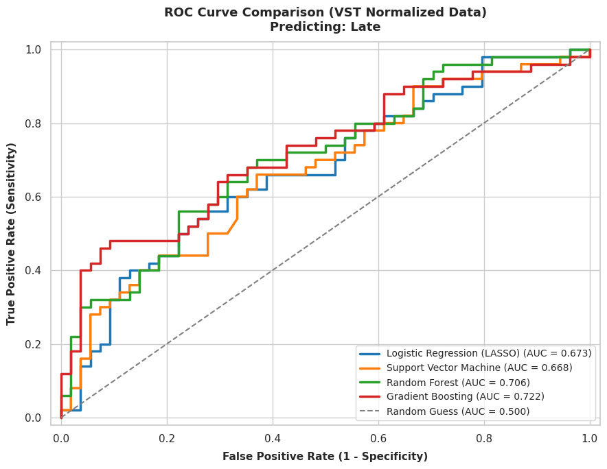

```python
run_subset_ml_pipeline(X_matrix=X_vst, y_target=y, title_suffix="VST Normalized Data")
```

```
Converting target classes ['Early' 'Late'] to binary integers...
```

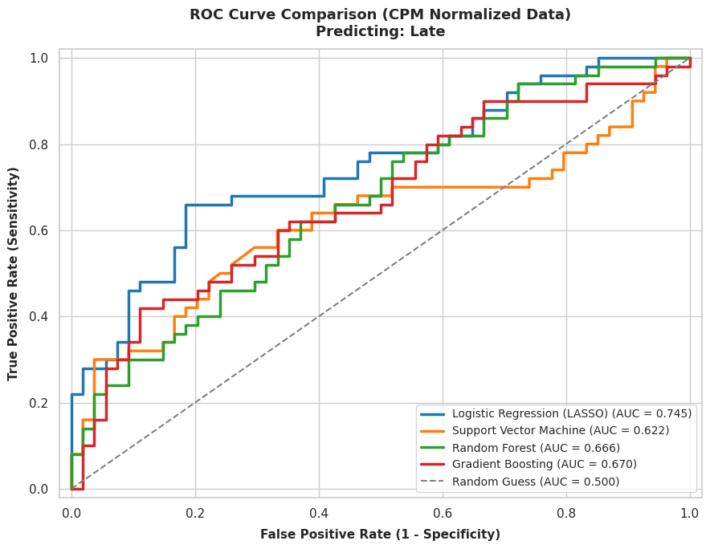

```python
run_subset_ml_pipeline(X_matrix=X_cpm, y_target=y, title_suffix="CPM Normalized Data")
```

## Classification Model Evaluation

CPM + StandardScaler data (lower) left the highly variable miRNA features loud and clear, which a linear selector like LASSO seems to have capitlized on given the highest AUC = 0.745. In contrast, VST data (upper) squeezed the variances of highly variable miRNA features down and while raising the influence of lowly expressed miRNA features, blending the signal into a complex mix that only decision trees could untangle. Thus, it is a logical result to see the VST data perfoming best with the Gradient Boosting model We will therefore select the CPM data LASSO regression and VST data Gradient Boosting models for further evaluation

## Hyperparameter tuning of selected models

Now that we have two baseline models we can try to further optimize by training with different hyper parameters to see if we can improve the ROC curves

### LASSO Regression - Hyperparameter tuning

```python
import numpy as np
import pandas as pd
import matplotlib.pyplot as plt
import seaborn as sns

from sklearn.model_selection import StratifiedKFold, cross_val_predict
from sklearn.preprocessing import StandardScaler
from sklearn.pipeline import Pipeline
from sklearn.linear_model import LogisticRegression
from sklearn.metrics import roc_curve, auc

def plot_roc_for_all_c_values(X_matrix, y_target):
    """
    Evaluates a spectrum of LASSO 'C' hyperparameters using Stratified 5-Fold CV
    and plots their out-of-fold ROC curves on a single unified canvas.
    """
    # 1. Standardize binary formatting for targets
    if not np.issubdtype(y_target.dtype, np.number):
        unique_classes = np.unique(y_target)
        y = (y_target == unique_classes[1]).astype(int)
    else:
        y = y_target.astype(int)

    # 2. Define the specific range of C values to evaluate
    # Smaller values = aggressive pruning; Larger values = relaxed, standard logistic limits
    c_values = [0.01, 0.05, 0.1, 0.5, 1.0, 5.0, 10.0]

    # 3. Initialize Cross-Validation strategy
    cv = StratifiedKFold(n_splits=5, shuffle=True, random_state=42)

    # 4. Canvas setup
    plt.figure(figsize=(11, 8))
    sns.set_theme(style="whitegrid")

    # Build a progressive color palette to make the chart easily scannable
    # Deep reds represent heavy regularization; vibrant blues indicate loose regularization
    palette = sns.color_palette("coolwarm_r", len(c_values))

    print("Generating cross-validated ROC curves for each C parameter value...")

    # 5. Iteratively fit pipelines and track curves
    for C_param, color in zip(c_values, palette):
        # Establish the specific pipeline for the current C iteration
        pipeline = Pipeline([
            ('scaler', StandardScaler()),
            ('lasso', LogisticRegression(penalty='l1', solver='liblinear', C=C_param, random_state=42, max_iter=1000))
        ])

        # Calculate cross-validated prediction probabilities for the positive class
        y_probs = cross_val_predict(pipeline, X_matrix, y, cv=cv, method='predict_proba')[:, 1]

        # Generate metrics
        fpr, tpr, _ = roc_curve(y, y_probs)
        roc_auc = auc(fpr, tpr)

        # Plot the individual parameter line
        plt.plot(
            fpr, tpr,
            color=color,
            lw=2.2,
            label=f'C = {C_param:<5} (AUC = {roc_auc:.3f})'
        )

    # Plot chance line
    plt.plot([0, 1], [0, 1], color='gray', lw=1.5, linestyle='--', label='Random Guess (AUC = 0.500)')

    # Chart adjustments
    plt.xlim([-0.02, 1.02])
    plt.ylim([-0.02, 1.02])
    plt.xlabel('False Positive Rate (1 - Specificity)', fontsize=11, fontweight='bold', labelpad=8)
    plt.ylabel('True Positive Rate (Sensitivity)', fontsize=11, fontweight='bold', labelpad=8)
    plt.title('LASSO Regularization Spectrum Analysis\nEvaluating Out-of-Fold ROC Curves across Hyperparameters',
              fontsize=14, fontweight='bold', pad=15)

    # Place legend cleanly outside or inside lower right
    plt.legend(loc="lower right", fontsize=10, frameon=True, facecolor='white', edgecolor='none')
    plt.tight_layout()
    plt.show()
```

```
Generating cross-validated ROC curves for each C parameter value...
```

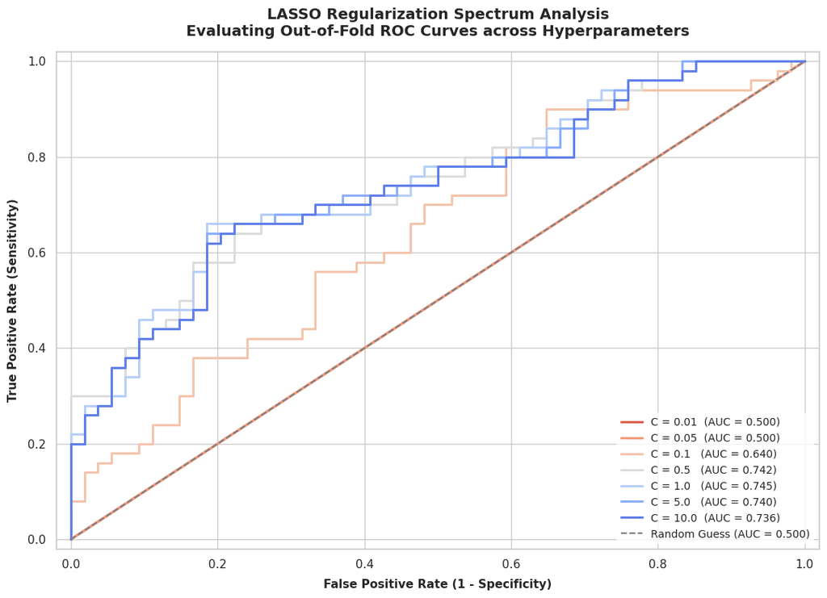

```python
plot_roc_for_all_c_values(X_matrix=X_cpm, y_target=y)
```

Tuning the C hyperparameter of the LASSO regression model provides no improvement to the AUC suggesting that improvement to the model would require a more informative data set for training. We accept this model as optimized and extract the LASSO predictions and probabilities for further performance evaluation later

```python
import numpy as np
import pandas as pd
from sklearn.model_selection import StratifiedKFold, cross_val_predict
from sklearn.preprocessing import StandardScaler
from sklearn.pipeline import Pipeline
from sklearn.linear_model import LogisticRegression

def extract_best_lasso_predictions(X_matrix, y_target, best_c=1.0):
    """
    Extracts out-of-fold predictions and probabilities for the selected best
    LASSO estimator configuration to feed a standalone metrics matrix.

    Parameters:
    -----------
    X_matrix : DataFrame or array
        Your input CPM feature matrix.
    y_target : array-like
        The diagnostic target labels.
    best_c : float, default=1.0
        The locked-in optimal regularized scale parameter.
    """
    # 1. Standardize binary formatting for targets
    if not np.issubdtype(y_target.dtype, np.number):
        unique_classes = np.unique(y_target)
        y = (y_target == unique_classes[1]).astype(int)
    else:
        y = y_target.astype(int)

    # 2. Re-initialize the exact cross-validation split mapping
    cv = StratifiedKFold(n_splits=5, shuffle=True, random_state=42)

    # 3. Establish the final optimized pipeline profile
    best_pipeline = Pipeline([
        ('scaler', StandardScaler()),
        ('lasso', LogisticRegression(
            penalty='l1',
            solver='liblinear',
            C=best_c,
            random_state=42,
            max_iter=1000
        ))
    ])

    print(f"Extracting out-of-fold cross-validation arrays for LASSO (C={best_c})...")

    # 4. Generate identical out-of-fold binary predictions and probabilities
    lasso_preds = cross_val_predict(best_pipeline, X_matrix, y, cv=cv, method='predict')
    lasso_probs = cross_val_predict(best_pipeline, X_matrix, y, cv=cv, method='predict_proba')[:, 1]

    print("Extraction complete. Ready for unified evaluation matrix processing.")

    return lasso_preds, lasso_probs
```

```python
lasso_cv_preds, lasso_cv_probs = extract_best_lasso_predictions(
    X_matrix=X_cpm,
    y_target=y,
    best_c=1.0
)
```

```
Extracting out-of-fold cross-validation arrays for LASSO (C=1.0)...
Extraction complete. Ready for unified evaluation matrix processing.
```

### Gradient Boosting - Hyperparameter tuning

Now let's try hyperparameter tuning the Gradient Boosting model with a parameter grid including multiple values for four hyperparameters

```python
import numpy as np
import pandas as pd
import matplotlib.pyplot as plt
import seaborn as sns

from sklearn.model_selection import StratifiedKFold, GridSearchCV, cross_val_predict
from sklearn.ensemble import GradientBoostingClassifier
from sklearn.metrics import roc_curve, auc

def optimize_gradient_boosting(X_matrix, y_target):
    """
    Tunes learning_rate, n_estimators, max_depth, and min_samples_split
    for Gradient Boosting using nested cross-validation to maximize VST AUC.
    """
    # 1. Clean format for binary targets
    if not np.issubdtype(y_target.dtype, np.number):
        unique_classes = np.unique(y_target)
        y = (y_target == unique_classes[1]).astype(int)
    else:
        y = y_target.astype(int)

    # 2. Define the core hyperparameter grid
    # Tree models are scale-invariant, so no StandardScaler pipeline step is needed here
    param_grid = {
        'learning_rate': [0.01, 0.05, 0.1, 0.2],
        'n_estimators': [50, 100, 150, 200],
        'max_depth': [2, 3, 4],
        'min_samples_split': [2, 5, 10]
    }

    # 3. Setup outer Stratified K-Fold validation loop
    outer_cv = StratifiedKFold(n_splits=5, shuffle=True, random_state=42)

    # 4. Set up internal Grid Search (Optimized explicitly for 'roc_auc')
    grid_search_estimator = GridSearchCV(
        estimator=GradientBoostingClassifier(random_state=42),
        param_grid=param_grid,
        cv=StratifiedKFold(n_splits=3, shuffle=True, random_state=42),
        scoring='roc_auc',
        n_jobs=-1
    )

    print("Executing nested hyperparameter tuning for Gradient Boosting across folds...")
    print("This may take a few moments due to the combinatorial grid space...")

    # 5. Extract cross-validated probabilities from the nested loops
    optimized_probs = cross_val_predict(
        grid_search_estimator,
        X_matrix,
        y,
        cv=outer_cv,
        method='predict_proba'
    )[:, 1]

    # 6. Calculate tuned performance metrics
    fpr, tpr, _ = roc_curve(y, optimized_probs)
    optimized_auc = auc(fpr, tpr)

    # 7. Fit on the full dataset to pull out the dominant param architecture
    grid_search_estimator.fit(X_matrix, y)
    best_params = grid_search_estimator.best_params_

    print("\n--- Tuning Summary ---")
    print("Original Baseline VST AUC: 0.722")
    print(f"Optimized Tuned VST AUC:  {optimized_auc:.3f}")
    print("Optimal Parameter Profile Found:")
    for param, value in best_params.items():
        print(f"  ↳ {param}: {value}")

    # 8. Plot the updated ROC Curve
    plt.figure(figsize=(8, 6))
    sns.set_theme(style="whitegrid")

    label_text = f"Tuned Gradient Boosting (AUC = {optimized_auc:.3f})"
    plt.plot(fpr, tpr, color='#2ca02c', lw=3, label=label_text)
    plt.plot([0, 1], [0, 1], color='gray', lw=1.5, linestyle='--', label='Random Guess (AUC = 0.500)')

    plt.xlim([-0.02, 1.02])
    plt.ylim([-0.02, 1.02])
    plt.xlabel('False Positive Rate (1 - Specificity)', fontsize=11, fontweight='bold')
    plt.ylabel('True Positive Rate (Sensitivity)', fontsize=11, fontweight='bold')
    plt.title('Tuned Gradient Boosting ROC Curve\n(Evaluated via 5-Fold Stratified CV on VST)', fontsize=13, fontweight='bold', pad=12)
    plt.legend(loc="lower right", frameon=True)
    plt.tight_layout()
    plt.show()

    return grid_search_estimator.best_estimator_
```

```
Executing nested hyperparameter tuning for Gradient Boosting across folds...
This may take a few moments due to the combinatorial grid space...

--- Tuning Summary ---
Original Baseline VST AUC: 0.722
Optimized Tuned VST AUC:  0.701
Optimal Parameter Profile Found:
  ↳ learning_rate: 0.01
  ↳ max_depth: 2
  ↳ min_samples_split: 2
  ↳ n_estimators: 50
```

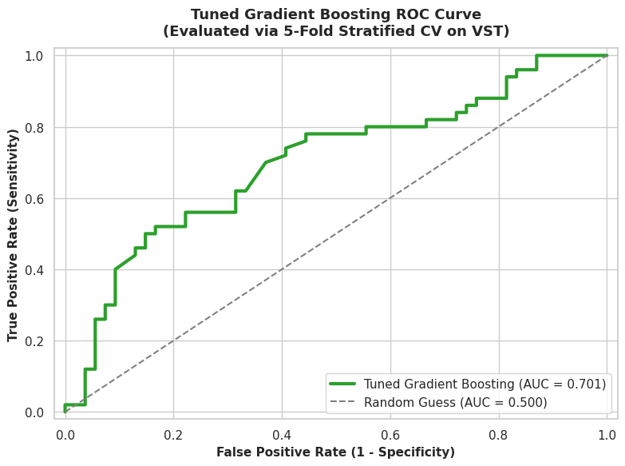

```
GradientBoostingClassifier(learning_rate=0.01, max_depth=2, n_estimators=50,
                           random_state=42)
```

```python
# Pass VST matrix and label array straight into the tuning pipeline
optimize_gradient_boosting(X_matrix=X_vst, y_target=y)
```

It seems the nested internal folds within stratified k fold is starving the model of training data, which makes it impossible for hyperparameter tuning to make an improvement to the model. Let's see what happens when we run the flat 5 folds without the internal 3 folds to retain a larger training set sample size

```python
import numpy as np
import pandas as pd
import matplotlib.pyplot as plt
import seaborn as sns

from sklearn.model_selection import StratifiedKFold, GridSearchCV, cross_val_predict
from sklearn.ensemble import GradientBoostingClassifier
from sklearn.metrics import roc_curve, auc

def optimize_and_extract_gradient_boosting(X_matrix, y_target):
    """
    Executes a flat Stratified 5-Fold Grid Search to tune Gradient Boosting on VST data.
    Plots the optimized ROC curve, and returns the best params alongside out-of-fold predictions.

    Returns:
    --------
    best_params : dict
        The hyperparameter configuration that yielded the highest CV AUC.
    optimized_preds : array
        Out-of-fold binary predictions (0/1) for the best model layout.
    optimized_probs : array
        Out-of-fold continuous probability scores for the best model layout.
    """
    # 1. Clean format for binary targets
    if not np.issubdtype(y_target.dtype, np.number):
        unique_classes = np.unique(y_target)
        y = (y_target == unique_classes[1]).astype(int)
    else:
        y = y_target.astype(int)

    param_grid = {
        'learning_rate': [0.01, 0.05, 0.1, 0.2],
        'n_estimators': [50, 100, 150, 200],
        'max_depth': [2, 3, 4],
        'min_samples_split': [2, 5, 10]
    }

    cv_strategy = StratifiedKFold(n_splits=5, shuffle=True, random_state=42)

    grid_search = GridSearchCV(
        estimator=GradientBoostingClassifier(random_state=42),
        param_grid=param_grid,
        cv=cv_strategy,
        scoring='roc_auc',
        n_jobs=-1
    )

    print("Executing Flat 5-Fold Grid Search Optimization on VST Matrix...")
    grid_search.fit(X_matrix, y)

    # Capture the winning architecture
    best_params = grid_search.best_params_
    best_model = grid_search.best_estimator_

    print("\n--- Hyperparameter Summary ---")
    print("Optimal Parameter Profile Located:")
    for param, value in best_params.items():
        print(f"  ↳ {param}: {value}")

    # 2. Extract out-of-fold binary predictions AND continuous probabilities for the winner
    print("Extracting out-of-fold predictions for the best estimator...")
    gb_preds = cross_val_predict(best_model, X_matrix, y, cv=cv_strategy, method='predict')
    gb_probs = cross_val_predict(best_model, X_matrix, y, cv=cv_strategy, method='predict_proba')[:, 1]

    # 3. Generate the optimized plotting visualization
    fpr, tpr, _ = roc_curve(y, gb_probs)
    curve_auc = auc(fpr, tpr)

    plt.figure(figsize=(8, 6))
    sns.set_theme(style="whitegrid")

    plt.plot(fpr, tpr, color='#2ca02c', lw=3, label=f'Tuned Gradient Boosting (AUC = {curve_auc:.3f})')
    plt.plot([0, 1], [0, 1], color='gray', lw=1.5, linestyle='--', label='Random Guess (AUC = 0.500)')

    plt.xlim([-0.02, 1.02])
    plt.ylim([-0.02, 1.02])
    plt.xlabel('False Positive Rate (1 - Specificity)', fontsize=11, fontweight='bold')
    plt.ylabel('True Positive Rate (Sensitivity)', fontsize=11, fontweight='bold')
    plt.title('Optimized Gradient Boosting ROC Curve\n(Flat 5-Fold Stratified CV on VST Data)', fontsize=13, fontweight='bold', pad=12)
    plt.legend(loc="lower right", frameon=True)
    plt.tight_layout()
    plt.show()

    # Return all three essential pipeline assets at once
    return best_params, gb_preds, gb_probs
```

```
Executing Flat 5-Fold Grid Search Optimization on VST Matrix...

--- Hyperparameter Summary ---
Optimal Parameter Profile Located:
  ↳ learning_rate: 0.01
  ↳ max_depth: 2
  ↳ min_samples_split: 5
  ↳ n_estimators: 200
Extracting out-of-fold predictions for the best estimator...
```

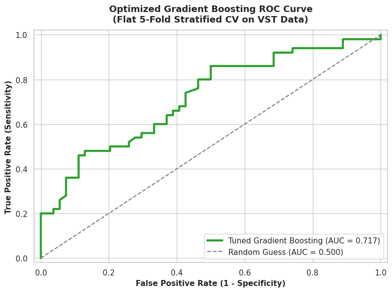

```python
# Train the non-nested setup on your VST dataframe
best_params, gb_preds, gb_probs = optimize_and_extract_gradient_boosting(X_matrix=X_vst, y_target=y)
```

The optimized Gradient Boosting model is no better than the baseline (AUC = 0.722) and roughly as well to the LASSO regression model (AUC=0.745). Now lets generate some more evaluation metrics to compare these two models.

```python
import numpy as np
import pandas as pd
from sklearn.metrics import accuracy_score, precision_score, recall_score, f1_score, roc_auc_score

def generate_model_evaluation_matrix(y_true, lasso_preds, lasso_probs, gb_preds, gb_probs):
    """
    Generates a single, combined performance evaluation table for the best-performing
    LASSO and Gradient Boosting configurations using pre-computed cross-validated outputs.
    """
    # 1. Map string labels ('Early', 'Late') to binary integers (0, 1) and cast to numpy
    y_true = np.asarray(y_true)
    if y_true.dtype.kind in {'U', 'S', 'O'}:  # Checks if data is string or object type
        mapping = {'Early': 0, 'Late': 1}
        # Vectorized mapping using np.vectorize or manual dictionary lookups
        y_true = np.array([mapping.get(val, val) for val in y_true])

    y_true = y_true.astype(int)

    l_preds = np.asarray(lasso_preds).astype(int)  # Ensure predictions are integers too
    l_probs = np.asarray(lasso_probs)

    gb_preds = np.asarray(gb_preds).astype(int)   # Ensure predictions are integers too
    gb_probs = np.asarray(gb_probs)

    # 2. Compute the parallel statistical profiles
    combined_metrics = {
        'Optimized LASSO (CPM Data)': {
            'Accuracy': accuracy_score(y_true, l_preds),
            'Precision': precision_score(y_true, l_preds, zero_division=0),
            'Recall': recall_score(y_true, l_preds),
            'F1-Score': f1_score(y_true, l_preds),
            'AUC-ROC': roc_auc_score(y_true, l_probs)
        },
        'Optimized Gradient Boosting (VST Data)': {
            'Accuracy': accuracy_score(y_true, gb_preds),
            'Precision': precision_score(y_true, gb_preds, zero_division=0),
            'Recall': recall_score(y_true, gb_preds),
            'F1-Score': f1_score(y_true, gb_preds),
            'AUC-ROC': roc_auc_score(y_true, gb_probs)
        }
    }

    # 3. Format into a single structural DataFrame
    df_matrix = pd.DataFrame(combined_metrics).T
    df_matrix = df_matrix.round(3)

    # 4. Stream out the unified Markdown display
    print("\n## Final Cross-Validated Performance Matrix")
    print("### Comparative Analysis of Best Model Architectures\n")
    print(df_matrix.to_markdown())

    return df_matrix
```

```python
import numpy as np
import matplotlib.pyplot as plt
from sklearn.metrics import confusion_matrix, ConfusionMatrixDisplay

def plot_comparative_confusion_matrices(y_true, lasso_preds, gb_preds):
    """
    Generates a side-by-side comparison subplot of confusion matrices
    for LASSO and Gradient Boosting models, handling string/integer labels.
    """
    # 1. Internal helper function for robust input processing (Label Mapping)
    def process_inputs(y_true_in, y_pred_in):
        y_true_arr = np.asarray(y_true_in)
        y_pred_arr = np.asarray(y_pred_in)

        # Check for string labels and map them to binary integers (0, 1)
        if y_true_arr.dtype.kind in {'U', 'S', 'O'}:
            mapping = {'Early': 0, 'Late': 1}
            y_true_arr = np.array([mapping.get(val, val) for val in y_true_arr])

        if y_pred_arr.dtype.kind in {'U', 'S', 'O'}:
            mapping = {'Early': 0, 'Late': 1}
            y_pred_arr = np.array([mapping.get(val, val) for val in y_pred_arr])

        return y_true_arr.astype(int), y_pred_arr.astype(int)

    # 2. Process both sets of inputs
    y_t_l, y_p_l = process_inputs(y_true, lasso_preds)
    y_t_g, y_p_g = process_inputs(y_true, gb_preds)

    # 3. Create the subplot structure (1 row, 2 columns)
    fig, axes = plt.subplots(1, 2, figsize=(14, 6), dpi=100)

    # Use consistent, professional color maps for visual distinctness
    # (Blues for the simpler linear model, Greens for the ensemble)
    cmaps = {'lasso': plt.cm.Blues, 'gb': plt.cm.Greens}
    display_labels = ['Early Stage', 'Late Stage']

    # --- Plot 1: LASSO Model ---
    cm_l = confusion_matrix(y_t_l, y_p_l)
    disp_l = ConfusionMatrixDisplay(confusion_matrix=cm_l, display_labels=display_labels)
    disp_l.plot(ax=axes[0], cmap=cmaps['lasso'], values_format='d', colorbar=False)

    axes[0].set_title('A) Optimized LASSO Model\n(CPM Data)', fontsize=12, fontweight='bold', pad=15)
    axes[0].set_xlabel('Predicted Label', fontsize=10)
    axes[0].set_ylabel('True Label', fontsize=10)

    # --- Plot 2: Gradient Boosting Model ---
    cm_g = confusion_matrix(y_t_g, y_p_g)
    disp_g = ConfusionMatrixDisplay(confusion_matrix=cm_g, display_labels=display_labels)
    disp_g.plot(ax=axes[1], cmap=cmaps['gb'], values_format='d', colorbar=False)

    axes[1].set_title('B) Optimized Gradient Boosting\n(VST Data)', fontsize=12, fontweight='bold', pad=15)
    axes[1].set_xlabel('Predicted Label', fontsize=10)
    axes[1].set_ylabel('') # Keep Y label subtle for comparison

    # Hide ticks on second plot Y-axis for cleaner side-by-side
    axes[1].tick_params(axis='y', which='both', length=0)
    axes[1].set_yticklabels([])

    # Aesthetic enhancements
    plt.suptitle('Cross-Validated Confusion Matrix Comparison', fontsize=14, fontweight='bold', y=0.98)
    plt.tight_layout(rect=[0, 0, 1, 0.95]) # Adjust tight layout to accommodate suptitle

    plt.show()

    return {'LASSO_CM': cm_l, 'GB_CM': cm_g}
```

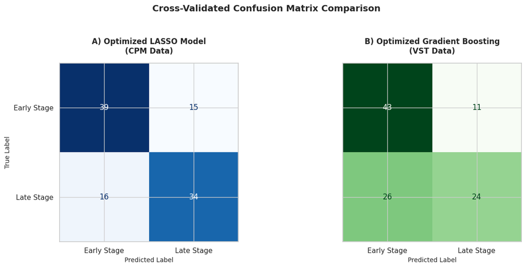

```
{'LASSO_CM': array([[39, 15],
        [16, 34]]),
 'GB_CM': array([[43, 11],
        [26, 24]])}
```

```python
plot_comparative_confusion_matrices(y, lasso_cv_preds, gb_preds)
```

```python
generate_model_evaluation_matrix(y, lasso_cv_preds, lasso_cv_probs, gb_preds, gb_probs)
```

```
## Final Cross-Validated Performance Matrix
### Comparative Analysis of Best Model Architectures

|                                        |   Accuracy |   Precision |   Recall |   F1-Score |   AUC-ROC |
|:---------------------------------------|-----------:|------------:|---------:|-----------:|----------:|
| Optimized LASSO (CPM Data)             |      0.702 |       0.694 |     0.68 |      0.687 |     0.745 |
| Optimized Gradient Boosting (VST Data) |      0.644 |       0.686 |     0.48 |      0.565 |     0.717 |
```

|  | Accuracy | Precision | Recall | F1-Score | AUC-ROC |
| --- | --- | --- | --- | --- | --- |
| Optimized LASSO (CPM Data) | 0.702 | 0.694 | 0.68 | 0.687 | 0.745 |
| Optimized Gradient Boosting (VST Data) | 0.644 | 0.686 | 0.48 | 0.565 | 0.717 |

## Model Comparison

The LASSO regression model outperforms the Gradient Boosting (GB) model in every evaluation metric, but especially in Recall or Sensitivity which is essential in clinical outcome prediction. The GB model is likely to miss many Late Stage cancer patients in comparison to the LASSO model.

Furthermore, logistic regression offers greater interpretability the Gradient Boosting which is essential for clinical genomics applications. Interestingly, the GB model outperforms LASSO in Specificity, predicting 43 patients of 54 in Early Stage cancer correctly.

# Feature importance

Now let us take a look at the features which had the greatest influence on the outcome variable. We will compare the LASSO model coefficients and the Gradient Boosting feature importance based on the Gini coefficient.

```python
import pandas as pd
import matplotlib.pyplot as plt
import seaborn as sns
from sklearn.preprocessing import StandardScaler
from sklearn.linear_model import LogisticRegression

def plot_lasso_coefficients(X_matrix, y_target):
    """
    Fits the top-performing LASSO Logistic Regression model on the full
    dataset and plots the resulting feature coefficients.
    """
    # 1. Ensure target vector is binary (0 and 1)
    # Assumes the second alphabetical class is the positive class (e.g., 'Late')
    if not pd.api.types.is_numeric_dtype(y_target):
        unique_classes = pd.unique(y_target)
        y = (y_target == unique_classes[1]).astype(int)
        pos_class_name = unique_classes[1]
    else:
        y = y_target.astype(int)
        pos_class_name = "Positive Class"

    # 2. Scale the features exactly like the cross-validation pipeline
    scaler = StandardScaler()
    X_scaled = scaler.fit_transform(X_matrix)

    # 3. Fit the final LASSO model
    # Using liblinear solver and C=1.0 to match your pipeline settings
    lasso = LogisticRegression(penalty='l1', solver='liblinear', C=1.0, random_state=42)
    lasso.fit(X_scaled, y)

    # 4. Extract coefficients (flattening the 2D array output)
    coefs = lasso.coef_[0]
    features = X_matrix.columns

    # Create a structured DataFrame for plotting
    coef_df = pd.DataFrame({
        'miRNA': features,
        'Coefficient': coefs
    })

    # Sort features by the absolute magnitude of their impact
    coef_df['Abs_Coef'] = coef_df['Coefficient'].abs()
    coef_df = coef_df.sort_values(by='Abs_Coef', ascending=False).drop(columns=['Abs_Coef'])

    # 5. Plotting Aesthetics
    plt.figure(figsize=(9, 6))
    sns.set_theme(style="whitegrid")

    # Map colors: Positive coefficients are Blue, Negative are Red, Zero is Gray
    colors = ['#1f77b4' if c > 0 else '#d62728' if c < 0 else '#7f7f7f' for c in coef_df['Coefficient']]

    # Horizontal barplot for easier miRNA string name scannability
    sns.barplot(
        data=coef_df,
        x='Coefficient',
        y='miRNA',
        palette=colors,
        hue='miRNA',  # Added to suppress seaborn deprecation warnings
        legend=False
    )

    # Add a vertical zero-axis guide line
    plt.axvline(x=0, color='black', linestyle='--', linewidth=1, alpha=0.7)

    # Dynamic labels and annotations
    plt.xlabel('LASSO Coefficient Weight (Standardized Scale)', fontsize=11, fontweight='bold', labelpad=8)
    plt.ylabel('Selected miRNA Features', fontsize=11, fontweight='bold')
    plt.title(f'LASSO Feature Impact Matrix\nPredicting: {pos_class_name}', fontsize=13, fontweight='bold', pad=12)

    # Clean padding and layout adjustments
    plt.tight_layout()
    plt.show()

    # Return the dataframe cleanly in case you want to print the raw numbers
    return coef_df
```

```python
from sklearn.ensemble import GradientBoostingClassifier

def plot_gb_importance(X_matrix, y_target):
    """
    Fits the top-performing Gradient Boosting model on the full VST dataset
    and returns its feature importance ranking.
    """
    # 1. Align binary target vector
    if not pd.api.types.is_numeric_dtype(y_target):
        unique_classes = pd.unique(y_target)
        y = (y_target == unique_classes[1]).astype(int)
    else:
        y = y_target.astype(int)

    # 2. Fit full Gradient Boosting model (matches pipeline defaults)
    gb = GradientBoostingClassifier(n_estimators=100, learning_rate=0.1, max_depth=3, random_state=42)
    gb.fit(X_matrix, y)

    # 3. Extract and sort importances (these sum up to 1.0)
    gb_df = pd.DataFrame({
        'miRNA': X_matrix.columns,
        'Importance': gb.feature_importances_
    }).sort_values(by='Importance', ascending=False)

    # 4. Plot
    plt.figure(figsize=(9, 6))
    sns.barplot(data=gb_df, x='Importance', y='miRNA', palette='viridis', hue='miRNA', legend=False)
    plt.xlabel('Relative Feature Importance (Gini Cleanliness Drop)', fontsize=11, fontweight='bold')
    plt.ylabel('Selected miRNA Features', fontsize=11, fontweight='bold')
    plt.title('Gradient Boosting Feature Importance (VST Data)', fontsize=13, fontweight='bold', pad=12)
    plt.tight_layout()
    plt.show()

    return gb_df
```

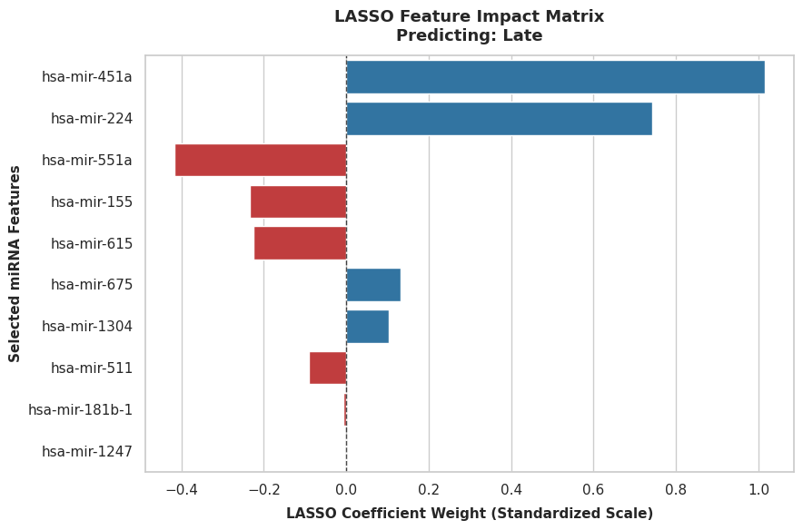

|  | miRNA | Coefficient |
| --- | --- | --- |
| 3 | hsa-mir-451a | 1.014371 |
| 1 | hsa-mir-224 | 0.742094 |
| 5 | hsa-mir-551a | -0.415838 |
| 2 | hsa-mir-155 | -0.232876 |
| 4 | hsa-mir-615 | -0.224377 |
| 6 | hsa-mir-675 | 0.131069 |
| 0 | hsa-mir-1304 | 0.104260 |
| 9 | hsa-mir-511 | -0.089838 |
| 8 | hsa-mir-181b-1 | -0.007923 |
| 7 | hsa-mir-1247 | 0.000000 |

```python
plot_lasso_coefficients(X_matrix=X_cpm, y_target=y)
```

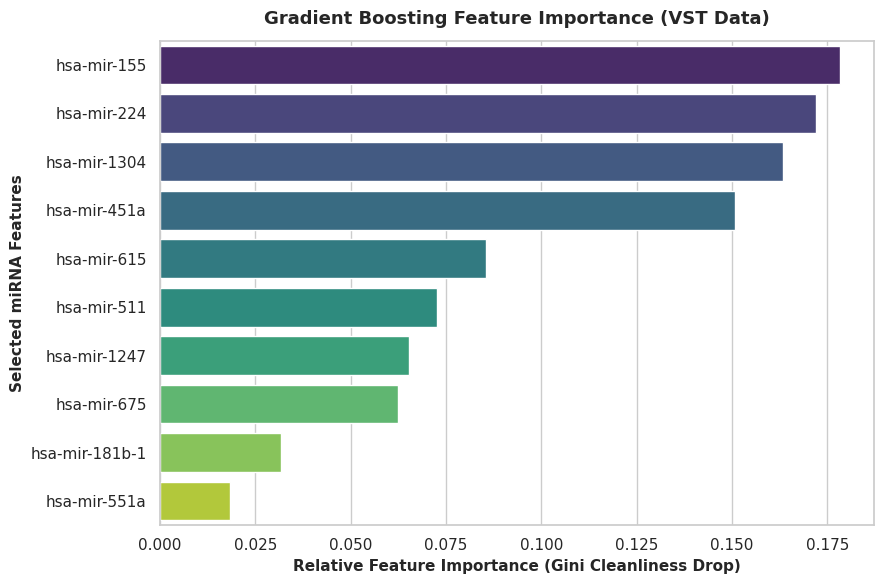

|  | miRNA | Importance |
| --- | --- | --- |
| 2 | hsa-mir-155 | 0.178308 |
| 1 | hsa-mir-224 | 0.172047 |
| 0 | hsa-mir-1304 | 0.163294 |
| 3 | hsa-mir-451a | 0.150766 |
| 4 | hsa-mir-615 | 0.085384 |
| 9 | hsa-mir-511 | 0.072505 |
| 7 | hsa-mir-1247 | 0.065396 |
| 6 | hsa-mir-675 | 0.062298 |
| 8 | hsa-mir-181b-1 | 0.031686 |
| 5 | hsa-mir-551a | 0.018317 |

```python
plot_gb_importance(X_matrix=X_vst, y_target=y)
```

As expected, the LASSO model places greater importance on a few miRNA features, in particular 'hsa-mir-451a', 'hsa-mir-224' while the Gradient Model spreads feature importance more equitably. Although the order is not identical both models share three of the four top miRNA features providing support for the general ranking of feature influence on the model.

## Boxplot for a miRNA of interest

Given the feature importance calculations it would be nice to plot the distribution of selected miRNA features. To do so, let's create a function that allows for the plotting of a boxplot for any miRNA in the dataset

```python
import matplotlib.pyplot as plt
import seaborn as sns
import pandas as pd
import numpy as np

def plot_mirna_expression(mirna_inputs, cpm_df, meta_df, stage_col):
    """
    Creates publication-quality boxplots for one or multiple specified miRNAs.

    Parameters:
    -----------
    mirna_inputs : str or list of str
        A single miRNA name or a list of miRNA names to visualize.
    cpm_df : pandas.DataFrame
        Pre-computed CPM dataframe (Samples as rows, miRNAs as columns).
    meta_df : pandas.DataFrame
        Clinical metadata dataframe.
    stage_col : str
        The target metadata column header for the x-axis groups.
    """
    # 1. Standardize input into a list even if a single string was passed
    if isinstance(mirna_inputs, str):
        mirna_list = [mirna_inputs]
    else:
        mirna_list = list(mirna_inputs)

    # 2. Filter out any requested miRNAs that don't exist in the data
    valid_mirnas = [m for m in mirna_list if m in cpm_df.columns]
    missing_mirnas = set(mirna_list) - set(valid_mirnas)

    if missing_mirnas:
        print(f"⚠️ Warning: The following features were not found in columns and will be skipped: {list(missing_mirnas)}")

    if not valid_mirnas:
        print("❌ Error: None of the requested miRNAs were found in the dataset columns.")
        return

    # 3. Calculate grid architecture dimensions dynamically (Max 3 columns wide)
    num_plots = len(valid_mirnas)
    num_cols = min(3, num_plots)
    num_rows = int(np.ceil(num_plots / num_cols))

    # Scale figure size proportionally based on grid rows/cols
    fig, axes = plt.subplots(num_rows, num_cols, figsize=(5 * num_cols, 5 * num_rows), dpi=100)

    # Ensure axes is an array even for a single plot to keep indexing stable
    if num_plots == 1:
        axes = np.array([axes])
    axes_flat = axes.flatten()

    # 4. Loop through each valid miRNA and render its plot panel
    for i, mirna_name in enumerate(valid_mirnas):
        ax = axes_flat[i]

        # Prepare Plotting Data (Direct alignment matching sample indices)
        plot_df = pd.DataFrame({
            'CPM': cpm_df[mirna_name].astype(float),
            'Stage': meta_df[stage_col]
        }).dropna()

        # Sort stages sequentially
        plot_df = plot_df.sort_values('Stage')

        # Boxplot distribution layer
        sns.boxplot(
            data=plot_df, x='Stage', y='CPM',
            palette="viridis", showfliers=False, width=0.5, ax=ax
        )

        # Individual patient data points layer
        sns.stripplot(
            data=plot_df, x='Stage', y='CPM',
            color="black", size=3.5, alpha=0.3, jitter=0.2, ax=ax
        )

        # Labels and polish styling per individual panel
        ax.set_title(f"{mirna_name}", fontsize=12, fontweight='bold', pad=10)
        ax.set_ylabel("Normalized Expression (CPM)", fontsize=10)
        ax.set_xlabel("AJCC Pathologic Stage", fontsize=10)
        ax.grid(axis='y', linestyle='--', alpha=0.3)

        # Clean overlapping label clutter if stages are densely named
        ax.set_xticklabels(ax.get_xticklabels(), rotation=30, ha='right')

    # 5. Hide empty subplot frames if our list doesn't perfectly fill the grid
    for j in range(num_plots, len(axes_flat)):
        fig.delaxes(axes_flat[j])

    sns.despine()
    plt.tight_layout()
    plt.show()
```

Now let's take a look at the two most important miRNA features from the LASSO regression model

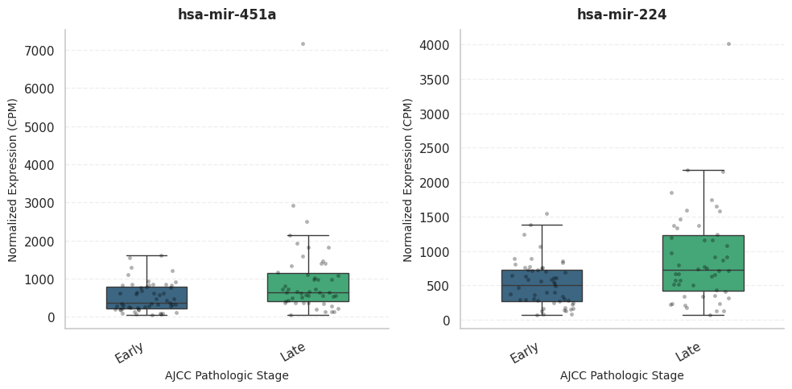

```python
my_biomarkers = ['hsa-mir-451a', 'hsa-mir-224']

plot_mirna_expression(
    mirna_inputs=my_biomarkers,
    cpm_df=cpm_filtered,
    meta_df=meta_df,
    stage_col='diagnoses.ajcc_pathologic_stage'
)
```

Both miRNA features show an increase in CPM in samples classified as Late stage although it should be noted both miRNA features do contain an outlier in the Late stage that increases the respective medians